# aksa

```python
import numpy as np
from keras.applications import VGG16
from keras.preprocessing import image
from keras.applications.vgg16 import preprocess_input
import pandas as pd
```

```python
DIR = "./flower_images/"
model = VGG16(weights='imagenet', include_top=False)
csv_data = pd.read_csv(DIR + "flower_labels.csv")
print(model.summary())
```

```
Model: "vgg16"
```

```
┏━━━━━━━━━━━━━━━━━━━━━━━━━━━━━━━━━┳━━━━━━━━━━━━━━━━━━━━━━━━┳━━━━━━━━━━━━━━━┓
┃ Layer (type)                    ┃ Output Shape           ┃       Param # ┃
┡━━━━━━━━━━━━━━━━━━━━━━━━━━━━━━━━━╇━━━━━━━━━━━━━━━━━━━━━━━━╇━━━━━━━━━━━━━━━┩
│ input_layer_1 (InputLayer)      │ (None, None, None, 3)  │             0 │
├─────────────────────────────────┼────────────────────────┼───────────────┤
│ block1_conv1 (Conv2D)           │ (None, None, None, 64) │         1,792 │
├─────────────────────────────────┼────────────────────────┼───────────────┤
│ block1_conv2 (Conv2D)           │ (None, None, None, 64) │        36,928 │
├─────────────────────────────────┼────────────────────────┼───────────────┤
│ block1_pool (MaxPooling2D)      │ (None, None, None, 64) │             0 │
├─────────────────────────────────┼────────────────────────┼───────────────┤
│ block2_conv1 (Conv2D)           │ (None, None, None,     │        73,856 │
│                                 │ 128)                   │               │
├─────────────────────────────────┼────────────────────────┼───────────────┤
│ block2_conv2 (Conv2D)           │ (None, None, None,     │       147,584 │
│                                 │ 128)                   │               │
├─────────────────────────────────┼────────────────────────┼───────────────┤
│ block2_pool (MaxPooling2D)      │ (None, None, None,     │             0 │
│                                 │ 128)                   │               │
├─────────────────────────────────┼────────────────────────┼───────────────┤
│ block3_conv1 (Conv2D)           │ (None, None, None,     │       295,168 │
│                                 │ 256)                   │               │
├─────────────────────────────────┼────────────────────────┼───────────────┤
│ block3_conv2 (Conv2D)           │ (None, None, None,     │       590,080 │
│                                 │ 256)                   │               │
├─────────────────────────────────┼────────────────────────┼───────────────┤
│ block3_conv3 (Conv2D)           │ (None, None, None,     │       590,080 │
│                                 │ 256)                   │               │
├─────────────────────────────────┼────────────────────────┼───────────────┤
│ block3_pool (MaxPooling2D)      │ (None, None, None,     │             0 │
│                                 │ 256)                   │               │
├─────────────────────────────────┼────────────────────────┼───────────────┤
│ block4_conv1 (Conv2D)           │ (None, None, None,     │     1,180,160 │
│                                 │ 512)                   │               │
├─────────────────────────────────┼────────────────────────┼───────────────┤
│ block4_conv2 (Conv2D)           │ (None, None, None,     │     2,359,808 │
│                                 │ 512)                   │               │
├─────────────────────────────────┼────────────────────────┼───────────────┤
│ block4_conv3 (Conv2D)           │ (None, None, None,     │     2,359,808 │
│                                 │ 512)                   │               │
├─────────────────────────────────┼────────────────────────┼───────────────┤
│ block4_pool (MaxPooling2D)      │ (None, None, None,     │             0 │
│                                 │ 512)                   │               │
├─────────────────────────────────┼────────────────────────┼───────────────┤
│ block5_conv1 (Conv2D)           │ (None, None, None,     │     2,359,808 │
│                                 │ 512)                   │               │
├─────────────────────────────────┼────────────────────────┼───────────────┤
│ block5_conv2 (Conv2D)           │ (None, None, None,     │     2,359,808 │
│                                 │ 512)                   │               │
├─────────────────────────────────┼────────────────────────┼───────────────┤
│ block5_conv3 (Conv2D)           │ (None, None, None,     │     2,359,808 │
│                                 │ 512)                   │               │
├─────────────────────────────────┼────────────────────────┼───────────────┤
│ block5_pool (MaxPooling2D)      │ (None, None, None,     │             0 │
│                                 │ 512)                   │               │
└─────────────────────────────────┴────────────────────────┴───────────────┘
```

```
 Total params: 14,714,688 (56.13 MB)
```

```
 Trainable params: 14,714,688 (56.13 MB)
```

```
 Non-trainable params: 0 (0.00 B)
```

```
None
```

Data Preprocessing and Feature Extraction 1.

1. High Dimensionality: Images are often represented by a large number of pixels, leading to high-dimensional data. Considering each pixel as a feature results in a very high-dimensional feature space, which can be computationally expensive and prone to the curse of dimensionality.
2. Irrelevant Information: Not all pixels contribute equally to the content or semantics of an image. Some pixels may represent background or noise rather than meaningful visual features. Extracting features allows the model to focus on relevant information and ignore irrelevant details.
3. Robustness to Variability: Images of the same object or scene can vary in lighting conditions, orientation, scale, and other factors. Feature extraction techniques aim to capture invariant characteristics of images, making clustering algorithms more robust to such variability.
4. Semantic Information: Features extracted from images often encode higher-level semantic information, such as texture, shape, and color, which may not be directly captured by individual pixels. This allows clustering algorithms to group together images with similar visual content, even if they have different pixel values.
5. Reduced Complexity: Feature extraction reduces the complexity of the data while retaining relevant information. By transforming the high-dimensional pixel space into a lower-dimensional feature space, clustering algorithms can operate more efficiently and effectively.
7. Histogram of Oriented Gradients (HOG): HOG is a feature descriptor used for object detection and recognition in images. It works by calculating the distribution of gradient orientations in localized portions of an image. The image is divided into small cells, and gradients (directional intensity changes) within each cell are computed using techniques like the Sobel operator. Histograms of gradient orientations are then computed for each cell, and these histograms are normalized to account for variations in illumination and contrast. Finally, the histograms are concatenated to form the feature vector representing the entire image or image region.
8. Scale-Invariant Feature Transform (SIFT): SIFT is a feature extraction algorithm that detects and describes local features in images. It identifies key points or interest points in the image that are invariant to scaling, rotation, and changes in viewpoint. SIFT operates by first identifying potential key points based on image gradients and other local properties. Then, it generates feature descriptors for each key point by considering the gradient magnitude and orientation in the surrounding region. These descriptors are designed to be robust to changes in scale, rotation, and illumination, making them suitable for tasks like image matching and object recognition.
9. Convolutional Neural Networks (CNNs): CNNs are a class of deep learning models that have revolutionized feature extraction in image processing tasks. They consist of multiple layers of convolutional, pooling, and fully connected layers. CNNs automatically learn hierarchical features from raw pixel data through the training process. Lower layers of the network learn low-level features such as edges and textures, while higher layers learn more abstract and complex features representing objects or object parts. CNNs have shown remarkable performance in various computer vision tasks, including image classification, object detection, and image segmentation, due to their ability to automatically learn discriminative features directly from the data.
11. Resizing: Images in a dataset may come in different sizes, but models typically require input images to have a fixed size. Resizing images to a standard size ensures consistency and enables efficient batch processing.
12. Normalization: Normalizing pixel values to a common scale can improve convergence during training. This typically involves scaling pixel values to the range [0, 1] or [-1, 1]. Normalization can help mitigate the effects of differences in brightness, contrast, or color balance across images.
13. Standardization: Standardizing pixel values by subtracting the mean and dividing by the standard deviation can help center the data around zero and give it unit variance. This can make optimization more stable and accelerate convergence.
14. Cropping: Cropping images to focus on the most relevant regions of interest can remove unnecessary background noise and improve model performance. For example, in object detection tasks, cropping may involve extracting bounding boxes around objects of interest.
15. Augmentation: Augmenting images through techniques such as rotation, flipping, scaling, or adding noise can increase the diversity of the training data and improve the model's ability to generalize to unseen images.
16. Grayscale Conversion: Converting color images to grayscale may be appropriate for tasks where color information is not relevant or detrimental to performance. Grayscale images have a single channel, which can reduce computational complexity and memory requirements.
17. Data Augmentation: Adding variations to the dataset such as rotation, translation, flipping, and zooming can help improve model generalization by exposing it to a wider range of possible input variations.
18. Removing Outliers: Occasionally, images may contain outliers, artifacts, or anomalies that could adversely affect model training. Identifying and removing such instances can improve the overall quality of the dataset.
19. Pretrained Models and Transfer Learning: Using pretrained models trained on large datasets (e.g., ImageNet) as feature extractors can be an effective form of preprocessing. Transfer learning allows leveraging knowledge learned from one task or dataset to improve performance on a different but related task or dataset.

```python
features = []
labels = []
for index, row in csv_data.iterrows():
    img_path = DIR + row['file']
    img = image.load_img(img_path, target_size=(224, 224))
    img_data = image.img_to_array(img)
    img_data = np.expand_dims(img_data, axis=0)
    preprocessed_data = preprocess_input(img_data)
    features_vector = model.predict(img_data)
    features.append(features_vector.flatten())
    labels.append(row['label'])
    print(img_path, row['label'])
```

```
1/1 ━━━━━━━━━━━━━━━━━━━━ 0s 212ms/step
./flower_images/0001.png 0
1/1 ━━━━━━━━━━━━━━━━━━━━ 0s 217ms/step
./flower_images/0002.png 0
1/1 ━━━━━━━━━━━━━━━━━━━━ 0s 232ms/step
./flower_images/0003.png 2
1/1 ━━━━━━━━━━━━━━━━━━━━ 0s 210ms/step
./flower_images/0004.png 0
1/1 ━━━━━━━━━━━━━━━━━━━━ 0s 206ms/step
./flower_images/0005.png 0
1/1 ━━━━━━━━━━━━━━━━━━━━ 0s 207ms/step
./flower_images/0006.png 1
1/1 ━━━━━━━━━━━━━━━━━━━━ 0s 243ms/step
./flower_images/0007.png 6
1/1 ━━━━━━━━━━━━━━━━━━━━ 0s 208ms/step
./flower_images/0008.png 0
1/1 ━━━━━━━━━━━━━━━━━━━━ 0s 210ms/step
./flower_images/0009.png 0
1/1 ━━━━━━━━━━━━━━━━━━━━ 0s 210ms/step
./flower_images/0010.png 0
1/1 ━━━━━━━━━━━━━━━━━━━━ 0s 211ms/step
./flower_images/0011.png 0
1/1 ━━━━━━━━━━━━━━━━━━━━ 0s 211ms/step
./flower_images/0012.png 0
1/1 ━━━━━━━━━━━━━━━━━━━━ 0s 215ms/step
./flower_images/0013.png 0
1/1 ━━━━━━━━━━━━━━━━━━━━ 0s 220ms/step
./flower_images/0014.png 7
1/1 ━━━━━━━━━━━━━━━━━━━━ 0s 224ms/step
./flower_images/0015.png 7
1/1 ━━━━━━━━━━━━━━━━━━━━ 0s 221ms/step
./flower_images/0016.png 1
1/1 ━━━━━━━━━━━━━━━━━━━━ 0s 218ms/step
./flower_images/0017.png 0
1/1 ━━━━━━━━━━━━━━━━━━━━ 0s 207ms/step
./flower_images/0018.png 0
1/1 ━━━━━━━━━━━━━━━━━━━━ 0s 250ms/step
./flower_images/0019.png 6
1/1 ━━━━━━━━━━━━━━━━━━━━ 0s 247ms/step
./flower_images/0020.png 0
```

[output cut: 365 more lines]

```
./flower_images/0203.png 8
1/1 ━━━━━━━━━━━━━━━━━━━━ 0s 208ms/step
./flower_images/0204.png 5
1/1 ━━━━━━━━━━━━━━━━━━━━ 0s 206ms/step
./flower_images/0205.png 4
1/1 ━━━━━━━━━━━━━━━━━━━━ 0s 209ms/step
./flower_images/0206.png 6
1/1 ━━━━━━━━━━━━━━━━━━━━ 0s 216ms/step
./flower_images/0207.png 0
1/1 ━━━━━━━━━━━━━━━━━━━━ 0s 211ms/step
./flower_images/0208.png 4
1/1 ━━━━━━━━━━━━━━━━━━━━ 0s 208ms/step
./flower_images/0209.png 6
1/1 ━━━━━━━━━━━━━━━━━━━━ 0s 220ms/step
./flower_images/0210.png 1
```

```python
for i in range(0, len(features)):
    print(labels[i], features[i].shape)
```

[output not shown]

```python
features = np.array(features)
print(len(features))
```

```
210
```

4. K-Means:

Pros:

```
Simple and easy to implement: K-Means is straightforward to understand and implement, making it suitable for beginners.
Scalability: K-Means can efficiently handle large datasets, as its time complexity is linear with the number of samples.
Cluster Interpretability: The clusters formed by K-Means tend to have a clear interpretation, especially when clusters are well-separated and have similar sizes.
Works well with spherical clusters: K-Means performs well when clusters are spherical or roughly spherical in shape.
```

Cons:

```
Sensitive to initial centroids: K-Means is sensitive to the initial placement of centroids, and different initializations can lead to different results.
Requires predefined number of clusters: K-Means requires the number of clusters to be specified in advance, which may not always be known.
Assumes clusters of similar size and density: K-Means assumes that clusters have similar sizes and densities, which may not always hold true in real-world datasets.
Susceptible to outliers: K-Means can be influenced by outliers, as they can significantly affect the positions of centroids.
```

5. In order to find the best fit of the clustering outcome, I came up with an array of numbers for clusters containing the main number and numbers close to it and plotted the outcomes so they can be nicely compared.

[output not shown]

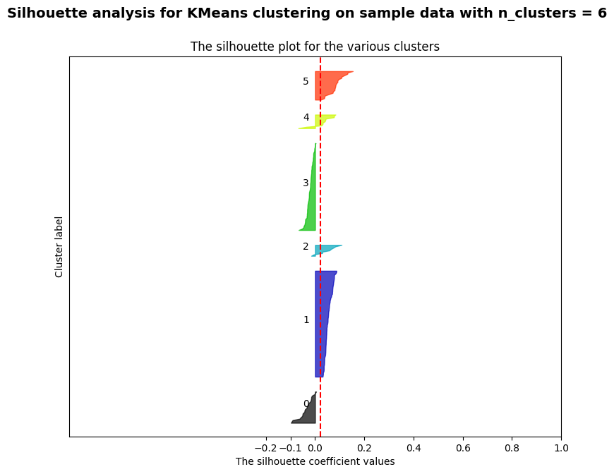

[output not shown]

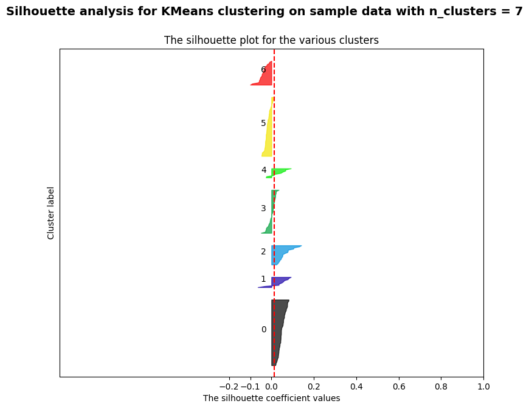

[output not shown]

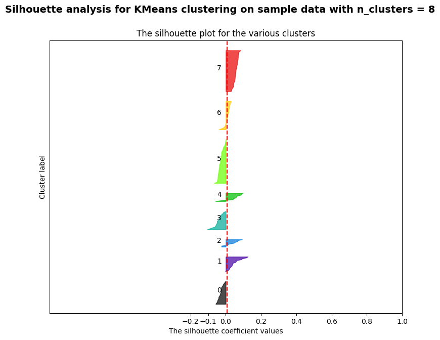

[output not shown]

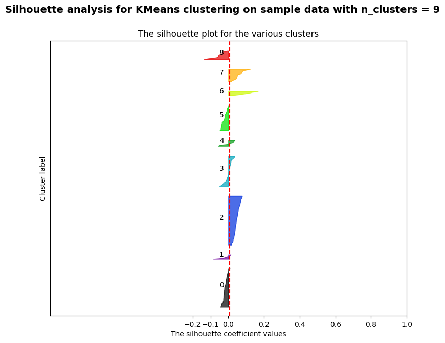

[output not shown]

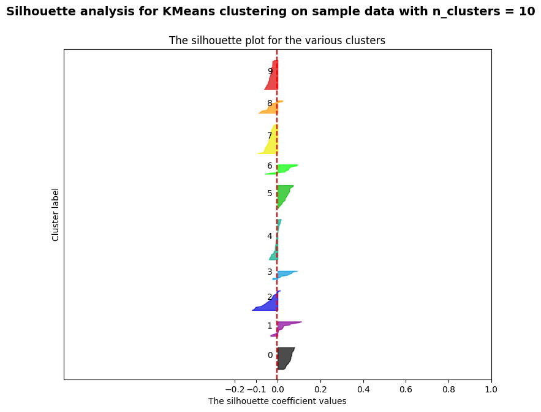

[output not shown]

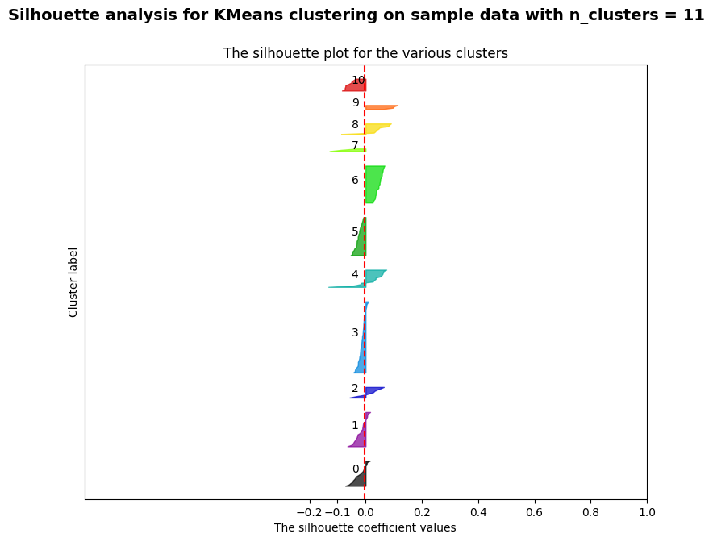

[output not shown]

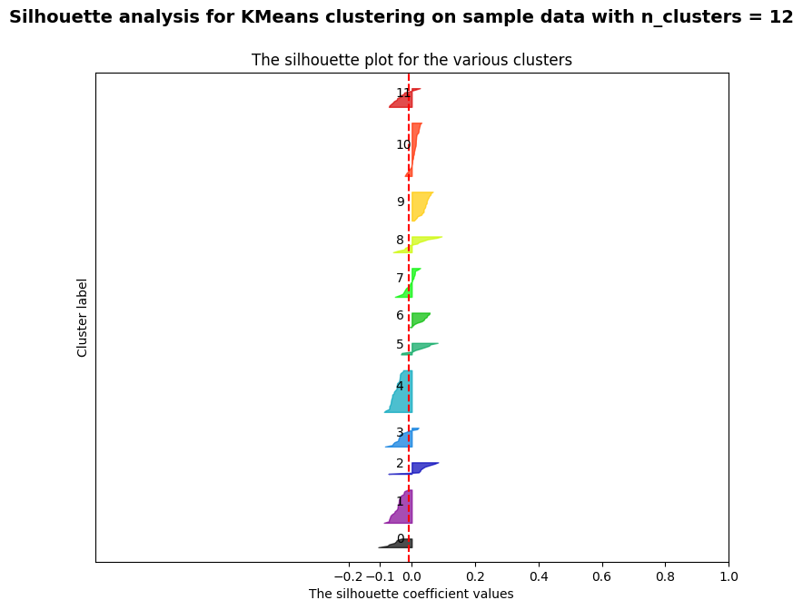

```python
from sklearn.decomposition import PCA
from sklearn.cluster import KMeans
import numpy as np
import matplotlib.cm as cm
import matplotlib.pyplot as plt
from sklearn.metrics import silhouette_samples, silhouette_score

range_n_clusters = [6, 7, 8, 9, 10, 11, 12]

for n_clusters in range_n_clusters:
    fig, ax1 = plt.subplots()
    fig.set_size_inches(9, 7)
    ax1.set_xlim([-1, 1])
    ax1.set_ylim([0, len(features) + (n_clusters + 1) * 10])

    reduced_features = PCA(n_components=2).fit_transform(features)
    kmeans = KMeans(n_clusters=n_clusters)
    kmeans.fit(reduced_features)

    sil_score_avg = silhouette_score(features, kmeans.labels_)
    print("cluster num :", n_clusters, " silhouette score :", sil_score_avg)
    smaple_score = silhouette_samples(features, kmeans.labels_)

    lowerbound_y = 10
    for i in range(n_clusters):
        i_cluster_score = smaple_score[kmeans.labels_ == i]
        i_cluster_score.sort()
        cluster_num = i_cluster_score.shape[0]
        upperbound_y = lowerbound_y + cluster_num

        color = cm.nipy_spectral(float(i) / n_clusters)
        ax1.fill_betweenx(np.arange(lowerbound_y, upperbound_y), 0, i_cluster_score, facecolor=color,
                          edgecolor=color, alpha=0.7)

        ax1.text(-0.05, lowerbound_y + 0.5 * cluster_num, str(i))
        lowerbound_y = upperbound_y + 10

    ax1.set_title("The silhouette plot for the various clusters")
    ax1.set_xlabel("The silhouette coefficient values")
    ax1.set_ylabel("Cluster label")
    ax1.axvline(x=sil_score_avg, color="red", linestyle="--")
    ax1.set_yticks([])
    ax1.set_xticks([-0.2, -0.1, 0, 0.2, 0.4, 0.6, 0.8, 1])

    plt.suptitle(
        "Silhouette analysis for KMeans clustering on sample data with n_clusters = %d"
        % n_clusters,
        fontsize=14,
        fontweight="bold",
    )

    plt.show()
```

```python
from sklearn.decomposition import PCA
from sklearn.cluster import KMeans
from sklearn.metrics import homogeneity_score, silhouette_score

range_n_clusters = [5, 6, 7, 8, 9, 10, 11, 12, 13, 14, 15]

for n in range_n_clusters:
    reduced_features = PCA(n_components=21).fit_transform(features)
    kmeans = KMeans(n_clusters=n)
    kmeans.fit(reduced_features)
    predicted_labels = kmeans.labels_
    selected_centers = kmeans.selected_centers_

    homogeneity = homogeneity_score(labels, predicted_labels)
    silhouette = silhouette_score(reduced_features, predicted_labels)

    fig, ax1 = plt.subplots(figsize=(10, 6))

    ax1.scatter(reduced_features[:, 0], reduced_features[:, 1], c=predicted_labels, cmap='viridis', s=50, alpha=0.5, label='Clustered Data Points')
    ax1.scatter(selected_centers[:, 0], selected_centers[:, 1], c='red', marker='x', s=200, label='Cluster Centers')
    ax1.set_title(f'Clustering Results (PCA)\nHomogeneity Score: {homogeneity:.2f}, Silhouette Score: {silhouette:.2f}')
    ax1.set_xlabel('dim 1')
    ax1.set_ylabel('dim 2')
    ax1.legend()

    plt.show()
```

4. DBSCAN:

Pros:

```
Ability to detect arbitrary-shaped clusters: DBSCAN can identify clusters of arbitrary shape and does not assume any specific cluster structure.
Robust to noise and outliers: DBSCAN is robust to noise and outliers because it does not assign outliers to any cluster and can handle varying cluster densities.
Automatic determination of number of clusters: DBSCAN does not require the number of clusters to be specified in advance. Instead, it automatically determines the number of clusters based on the density of the data.
No sensitivity to initializations: Unlike K-Means, DBSCAN does not depend on initial centroids and is therefore not sensitive to initialization.
```

Cons:

```
Difficulty in determining optimal parameters: DBSCAN requires specifying two parameters - epsilon (ε) and minimum points (MinPts), which can be challenging to determine, especially for datasets with varying densities.
Sensitivity to choice of distance metric: DBSCAN's performance can be influenced by the choice of distance metric, and selecting an appropriate distance measure is crucial.
Memory and computational requirements: DBSCAN's time and space complexity can be relatively high, especially for large datasets, due to its need to compute pairwise distances between all data points.
Potential issues with high-dimensional data: In high-dimensional spaces, the notion of distance becomes less reliable, which can impact DBSCAN's performance. Dimensionality reduction techniques may be needed preprocessing steps.
```

```python
from sklearn.cluster import DBSCAN

epsilon = 80
min_samples = 2
reduced_features = PCA(n_components=2).fit_transform(features)
dbscan_predicted_labels = DBSCAN(eps=epsilon, min_samples=min_samples).fit_predict(reduced_features)
print(dbscan_predicted_labels)
print(f"homogeneity score of kmeans: {homogeneity_score(labels,dbscan_predicted_labels)}")
print(f"silhouette score of kmeans: {silhouette_score(features,dbscan_predicted_labels)}")
```

```
[ 0  0  1  2  0  0  0  0  0  0  0  0  0  0  3  0  0  2  0  0  3 -1  0 -1
  0 -1 -1  0  0 -1  0  0  0  0  0  0  0  0 -1  0  0  0  0  0  0  4  0  0
  2  0  0 -1  0  0  0  5  0  0  0 -1  3  6  0  3  0  0  0  6  7  8  0  0
  0  0  0  0  9  0 10  0  0 -1  0  0  0  0 -1 -1  5 -1  0  0  0 -1  0  0
  2  0  0  0  0  1  8  0  0  3 -1  0  0  0  0  8 11  0  0  0  9  5  0 -1
  0  1 12  0  0  0  0  0  0  9  0 11  0 -1  0 -1  0  5  3  8  0 -1  0  0
 -1 13 -1 -1  0  0  0 -1  0  0  0  0  0  0  0  0  0  0  0  0  0  0  0  0
  0  0  0  0  0  0  0  0  0  4  0  0  0  0 10  2  0  0  0 -1  0 13 -1  0
  0  0  5  0  0  0  7 -1  0  0  0  0 12 -1  0 -1  2  0]
homogeneity score of kmeans: 0.26159318331325654
silhouette score of kmeans: -0.08535242825746536
```

```
Silhouette score for epsilon=50: -0.07833542674779892
Number of clusters for epsilon=50: 24
Homogeneity score for epsilon=50: 0.37740178755863046
Silhouette score for epsilon=60: -0.0395682193338871
Number of clusters for epsilon=60: 18
Homogeneity score for epsilon=60: 0.32298828871587787
Silhouette score for epsilon=70: -0.08725502341985703
Number of clusters for epsilon=70: 15
Homogeneity score for epsilon=70: 0.26030345551047035
Silhouette score for epsilon=80: -0.08535242825746536
Number of clusters for epsilon=80: 14
Homogeneity score for epsilon=80: 0.26159318331325654
Silhouette score for epsilon=90: 0.006953810341656208
Number of clusters for epsilon=90: 11
Homogeneity score for epsilon=90: 0.1865676936089855
Silhouette score for epsilon=100: 0.007231106515973806
Number of clusters for epsilon=100: 12
Homogeneity score for epsilon=100: 0.18539714525702677
Silhouette score for epsilon=110: 0.010039123706519604
Number of clusters for epsilon=110: 11
Homogeneity score for epsilon=110: 0.18837418537657044
Silhouette score for epsilon=120: 0.012425048276782036
Number of clusters for epsilon=120: 10
Homogeneity score for epsilon=120: 0.1840558193400544
Silhouette score for epsilon=130: 0.012425048276782036
Number of clusters for epsilon=130: 10
Homogeneity score for epsilon=130: 0.1840558193400544
Silhouette score for epsilon=140: 0.013149951584637165
Number of clusters for epsilon=140: 7
Homogeneity score for epsilon=140: 0.16622885846364482
Silhouette score for epsilon=150: 0.017667977139353752
Number of clusters for epsilon=150: 5
Homogeneity score for epsilon=150: 0.12996058959065201
```

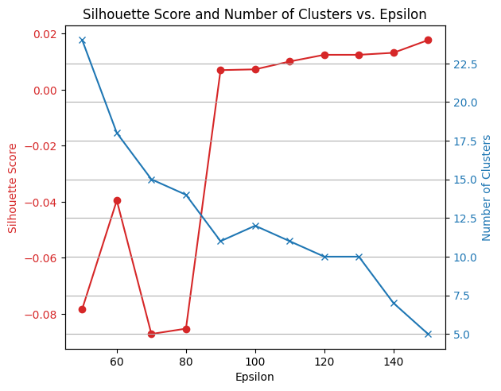

```python
from sklearn.cluster import DBSCAN

silhouette_eps_min_samples = []
DBSCAN_EPS_RANGE = [50, 60, 70, 80, 90, 100, 110, 120, 130, 140, 150]
DBSCAN_EPS_RANGE = np.array(DBSCAN_EPS_RANGE)
epsilon = 52
min_samples = 2
eps_s = []
num_clusters = []

for eps in DBSCAN_EPS_RANGE:
    reduced_features = PCA(n_components=2).fit_transform(features)
    dbscan_predicted_labels = DBSCAN(eps=eps, min_samples=min_samples).fit_predict(reduced_features)
    silhouette_score_val = silhouette_score(features, dbscan_predicted_labels)
    silhouette_eps_min_samples.append(silhouette_score_val)

    num_unique_clusters = len(set(dbscan_predicted_labels)) - (1 if -1 in dbscan_predicted_labels else 0)
    num_clusters.append(num_unique_clusters)

    print(f"Silhouette score for epsilon={eps}: {silhouette_score_val}")
    print(f"Number of clusters for epsilon={eps}: {num_unique_clusters}")
    print(f"Homogeneity score for epsilon={eps}: {homogeneity_score(labels, dbscan_predicted_labels)}")

fig, ax1 = plt.subplots()

color = 'tab:red'
ax1.set_xlabel('Epsilon')
ax1.set_ylabel('Silhouette Score', color=color)
ax1.plot(DBSCAN_EPS_RANGE, silhouette_eps_min_samples, marker='o', color=color)
ax1.tick_params(axis='y', labelcolor=color)

ax2 = ax1.twinx()
color = 'tab:blue'
ax2.set_ylabel('Number of Clusters', color=color)
ax2.plot(DBSCAN_EPS_RANGE, num_clusters, marker='x', color=color)
ax2.tick_params(axis='y', labelcolor=color)

fig.tight_layout()
plt.title('Silhouette Score and Number of Clusters vs. Epsilon')
plt.xlabel('Epsilon')
plt.grid(True)
plt.show()
```

Principal Component Analysis (PCA) is a dimensionality reduction technique widely used in various fields, including machine learning, statistics, and signal processing. Its primary purpose is to transform high-dimensional data into a lower-dimensional representation while preserving the most important information. PCA reduces the dimensionality of the data by transforming it into a new set of variables (principal components) that capture the most important information. This is particularly useful when dealing with datasets with a large number of features.

```
PCA begins by computing the covariance matrix of the original data. The covariance matrix provides information about the relationships between different features (variables) in the dataset.

The next step involves finding the eigenvectors and eigenvalues of the covariance matrix. Eigenvectors represent the directions of maximum variance in the data, and eigenvalues quantify the amount of variance along those directions.

PCA orders the eigenvectors based on their corresponding eigenvalues in descending order. The eigenvector with the highest eigenvalue represents the principal component with the most significant variance in the data. Subsequent eigenvectors capture decreasing amounts of variance.

The selected eigenvectors (principal components) are used to create a transformation matrix. The original data is then projected onto this lower-dimensional subspace defined by the principal components.
```

Analysis and Assesment

Homogeneity Score

The Homogeneity Score is a metric designed to evaluate the quality of clustering results by assessing how well the clusters align with the true classes or labels of the data. Specifically, it measures the degree to which each cluster predominantly consists of data points from a single class, providing insights into the cohesion of clusters with respect to class membership.

steps of execution:

[output not shown]

where N is the total number of samples, N_cluster is the number of samples in the cluster, and max(class_count) is the count of the most frequent class label within the cluster.

Silhouette Score

The silhouette score evaluates the fitness of each sample within its assigned cluster and its distinctiveness from samples in neighboring clusters. This metric offers insights into both the cohesion within clusters and the separation between clusters. The silhouette score is a numerical measure that falls within the range of -1 to 1.

steps of execution:

[output not shown]

[output not shown]